# R Markdown

## R Markdown

**What is it** * R Markdown is a file format for making dynamic documents

**Who is it for** * For communicating to decision makers, who want to focus on the conclusions, not the code behind the analysis.

- For collaborating with other data scientists (including future you!), who are interested in both your conclusions, and how you reached them (i.e. the code).
- As an environment in which to do data science, as a modern day lab notebook where you can capture not only what you did, but also what you were thinking.

## Types of R Markdown output

- Documents (HTML, PDF, Word, RTF, Markdown)
- Presentations
  - ioslides (HTML)
  - Beamer (PDF)
  - PowerPoint (PowerPoint)
- Journals
  - elsevier_article _ jss_article
- Dashboards
  - Flexdashboard
- Websites and blogs
  - blogdown
- Books
  - bookdown (HTML, PDF, ePUB and Kindle books)

## R Markdown code

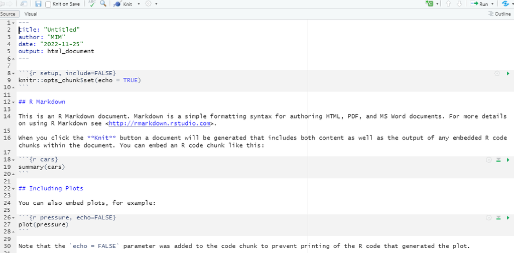

## What does R Markdown contains

It contains three important types of content:

- An (optional) YAML header surrounded by —s.
- Chunks of R code surrounded by ```.
- Text mixed with simple text formatting like # heading and *italics*.

## How does R Markdown works

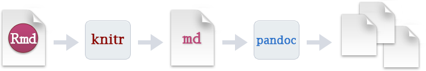

…but just push (ctrl+shift+K) the Knit icon.

## YAML

## YAML

YAML - “yet another markup language”

- Controls many “whole document” settings
- Possible to set document parameters
- Possible to specify bibliography

RStudio creates a YAML header when starting from scratch with *File \(\rightarrow\) New File \(\rightarrow\) R Markdown…*

## Text

## Text

Examples

- *italic* gives *italic*
- **bold** gives **bold**
- ~~Strikethrough~~ gives Strikethrough
- superscript^2^subscript~2~ gives superscript<sup>2</sup>/subscript<sub>2</sub>
- $e^{i\pi}+1=0$ gives \(e^{i\pi}+1=0\)
- `` `r nrow(mice::boys)` `` gives 748
- Headers:
- # Level 1 header
- ## Level 2 header

## Simple table

`Right | Left | Default | Center |`  
`|-------:|:------|-----------|:---------:|`  
`| 12 | 12 | 12 | 12 |`  
`| 123 | 123 | 123 | 123 |`  
`| 1 | 1 | 1 | 1 |`

Gives:

| Right | Left | Default | Center |
| --- | --- | --- | --- |
| 12 | 12 | 12 | 12 |
| 123 | 123 | 123 | 123 |
| 1 | 1 | 1 | 1 |

## Lists

`* Blah Blah`  
`* Blah`

gives

- Blah Blah
- Blah

`1. Blah Blah`  
`2. Blah`

gives

1. Blah Blah
2. Blah

## Code chunks

## Chunk header

2 parts:

- Name (optional)
  - easier navigation with drop-down code navigator
  - easier debugging
  - Graphics produced will have names that make them easier to use elsewhere
- options (optional)
  - customises chunk output

## Example

````
```{r ShowCode, eval=FALSE}
#No evaluation but shows code
ggplot(data = mice::boys, aes(age, bmi)) +
  geom_point()
```
````

gives

```r
#No evaluation but shows code
ggplot(data = mice::boys, aes(age, bmi)) +
  geom_point()
```

## Example

````
```{r OnlyFig, echo=FALSE, warning=FALSE}
#Shows only figure - no warnings
ggplot(data = mice::boys, aes(age, bmi)) +
  geom_point()
```
````

gives \(\rightarrow\)

## Example

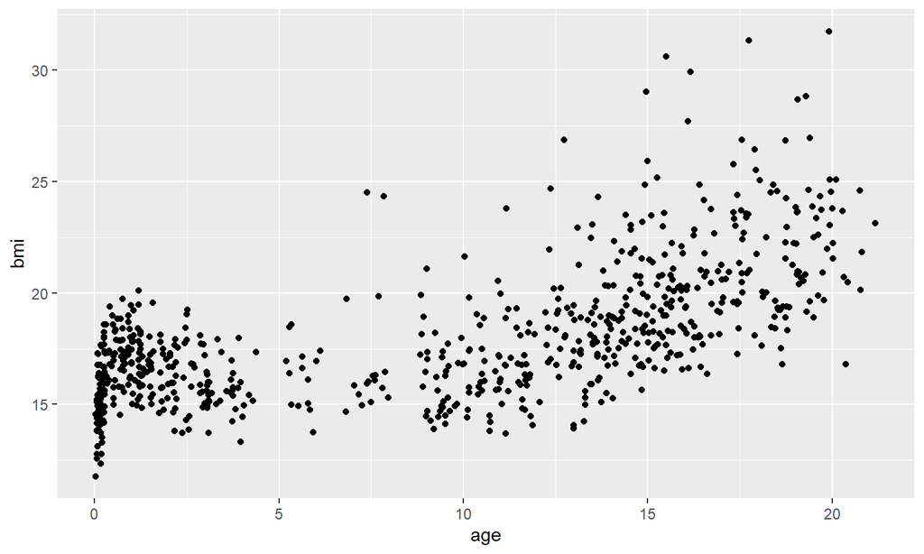

## Options

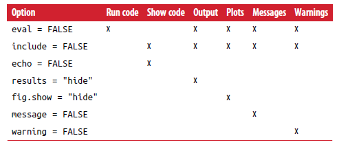

## Tables - (normal print)

Printing tables to markdown aren’t pretty. But with the package *kableExtra* it is easy to make readable tabels.

```r
boys %>%
  select(-gen, -phb, -tv) %>%
  slice_head(n=5)
```

```
##     age  hgt  wgt   bmi   hc   reg
## 1 0.035 50.1 3.65 14.54 33.7 south
## 2 0.038 53.5 3.37 11.77 35.0 south
## 3 0.057 50.0 3.14 12.56 35.2 south
## 4 0.060 54.5 4.27 14.37 36.7 south
## 5 0.062 57.5 5.03 15.21 37.3 south
```

## Tables - `knitr::kable`

```r
boys %>%
  select(-gen, -phb, -tv, -hc) %>%
  arrange(age) %>%
  slice_head(n=5) %>%
  knitr::kable(format = "html",
               col.names = c("Age","Height","Weight","BMI", "Region"),
               align = "ccccc",
               caption = "The 5 youngest boys")
```

The 5 youngest boys

| Age | Height | Weight | BMI | Region |
| --- | --- | --- | --- | --- |
| 0.035 | 50.1 | 3.65 | 14.54 | south |
| 0.038 | 53.5 | 3.37 | 11.77 | south |
| 0.057 | 50.0 | 3.14 | 12.56 | south |
| 0.060 | 54.5 | 4.27 | 14.37 | south |
| 0.062 | 57.5 | 5.03 | 15.21 | south |

## Tables - `knitr::kable` and `KableExtra`

```r
boys %>%
  select(-gen, -phb, -tv, -hc) %>%
  arrange(age) %>%
  slice_head(n=5) %>%
  knitr::kable(col.names = c("Age","Height","Weight","BMI", "Region"),
               align = "ccccc",
               caption = "<font size=3>The 5 youngest boys</font>") %>%
  kable_styling(bootstrap_options = c("hover"),
                full_width = FALSE, position = "left")
```

The 5 youngest boys

| Age | Height | Weight | BMI | Region |
| --- | --- | --- | --- | --- |
| 0.035 | 50.1 | 3.65 | 14.54 | south |
| 0.038 | 53.5 | 3.37 | 11.77 | south |
| 0.057 | 50.0 | 3.14 | 12.56 | south |
| 0.060 | 54.5 | 4.27 | 14.37 | south |
| 0.062 | 57.5 | 5.03 | 15.21 | south |

## Shiny

“Shiny is an R package that makes it easy to build interactive web apps straight from R. You can host standalone apps on a webpage or embed them in R Markdown documents or build dashboards. You can also extend your Shiny apps with CSS themes, htmlwidgets, and JavaScript actions.”

From https://shiny.rstudio.com/